# 데이터 과학

`gitlab` 환경설정과 기본사용법

xwMOOC

Tidyverse Korea

2019-11-05

[figure not shown]

WSL R마크다운 작업 환경

# 1 `Git` 호스팅 서비스 비교 [^1]

`Git` 호스팅 서비스를 제공하는 곳은 GitHub, Bitbucket, Gitlab 세곳이 유명하다. [EjongHyuck (2017. 5. 16.),“Git 호스팅 3대장 가성비 비교”](https://m.blog.naver.com/dlwhdgur20/221006619001) 블로그를 통해서 각 Git 호스팅 업체 장단점을 비교해본다. 아마도 오픈소스 목적의 프로젝트인 경우 Github을 추천하고 개인적인 프로젝트라던가 상용화 목적인 경우 Gitlab을 많이 추천한다.

- [GitHub](http://github.com/): 마이크로소프트 인수
- [Bitbucket](https://bitbucket.com/): Atlassian
- [**Gitlab**](http://gitlab.com/)

# 2 `gitlab` 설치 [^2]

`gitlab` 설치에 앞서 `curl` 등 필요한 도구를 설치한다.

```r
$ sudo apt-get update
$ sudo apt install curl openssh-server ca-certificates postfix
```

`gitlab`을 다운로드 받아 설치한다.

```r
$ curl -sS https://packages.gitlab.com/install/repositories/gitlab/gitlab-ce/script.deb.sh | sudo bash
$ sudo apt install gitlab-ce # 시간이 조금 오래 걸림
```

# 3 `gitlab.com` 호스팅 서비스 연결

`gitlab`을 설치한 후에 로컬 컴퓨터에서 시간여행이 가능한 코드관리를 하더라도 협업과 백업 목적으로 `gitlab.com` 웹호스팅을 연결하는 것이 일반적이다.

## 3.1 SSH [^3]

다음 방식으로 ssh-key를 생성해서 `gitlab.com` 웹호스트에 저장시킨다.

1. `gitbash.exe` 실행시킨 후에 `ssh-keygen`을 실행
2. `id_rsa.pub` 공개키를 복사해서 서버에 등록한다.
3. Gitlab 서버에 접속해서 사용자 > 프로파일 > 편집 > SSH Keys 메뉴로 이동하여 `id_rsa.pub` 공개키를 복사하여 등록

즉, `User Settings` > `SSH Keys` 메뉴로 들어가서 SSH Key에 대한 내용을 잘 읽고 절차대로 진행하면 된다. ‘~/.ssh/id_rsa.pub’ 파일을 열어 **Key** 복사하여 붙여넣는다.

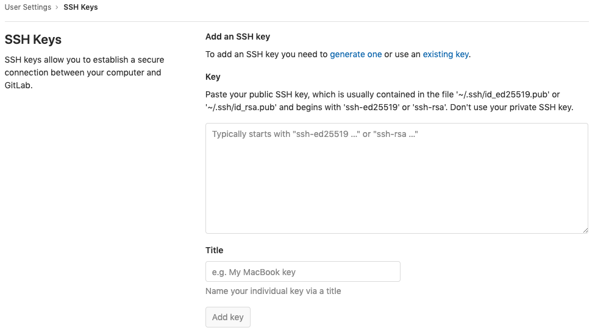

`gitlab` 공개키 등록

## 3.2 Gitlab 저장소 인증: **Windows 자격 증명**

Gitlab 저장소를 `git clone`할 경우 `git`은 포트 22 대신, `https`를 사용할 경우 다음과 같이 **Windows 자격 증명**을 활용하여 로컬 컴퓨터에 클론해 온다.

1. “윈도우키 + R” 단축키를 눌러 `netplwiz` 명령어를 실행
2. “사용자 계정” → “고급” → “암호관리”로 들어간다.
3. “자격 증명 관리자” → **Windows 자격 증명**을 선택하고 `gitlab` 웹 저장소 설정을 맞춘다.

[figure not shown]

제어판계정증명 관리자

# 4 `gitlab` 작업흐름

## 4.1 `gitlab` 기본작업 흐름

`git add` → `git commit - m` → `git push origin master` 작업흐름이 가장 기본적인 `gitlab` 작업흐름이라고 할 수 있다.

```r
$ git add -A
$ git commit -m "added the most important feature ever before"
$ git push origin master
```

## 4.2 `gitlab` 가지따기(`branch`) [^4]

`git` `master` 브랜치로 작업하는 것은 혼자서 모든 권한을 가지고 작업할 때 유용하다. 두 사람이상 여러명이 함께 개발작업을 할 경우 가지따기(`branch`) 즉 브랜치를 따서 작업하는 것이 유용하다.

`git checkout -b`로 브랜치를 생성하는 것부터 `git push origin :new_feature`까지 작업 완료 후 브랜치를 삭제한다.

```r
$ git checkout -b new_feature # `new_feature` 브랜치 생성
... # `new_feature` 기능 구현
$ git add -A # 작업 결과 Staging Area 저장
$ git commit -m "finish up the latest feature ever before" # 커밋
$ git push origin new_feature # new_feature 브랜치에 결과 푸쉬
$ git branch --set-upstream-to origin/new_feature
$ git checkout master # `master` 브랜치 작업 시작
$ git branch --delete new_feature # 로컬 `new_feature` 브랜치 삭제
$ git branch -D new_feature # 로컬 `new_feature` 브랜치 삭제
$ git push origin :new_feature # 호스팅된 `new_feature` 브래치 삭제
```

[^1]: [EjongHyuck (2017. 5. 16.),“Git 호스팅 3대장 가성비 비교”](https://m.blog.naver.com/dlwhdgur20/221006619001)
[^2]: [How to Install and Configure GitLab on Ubuntu 16.04](https://www.howtoforge.com/tutorial/how-to-install-and-configure-gitlab-on-ubuntu-16-04/)
[^3]: [GitLab: SSH Key 등록 후, Source Clone 받기](https://m.blog.naver.com/semidex37/220951282334)
[^4]: [Git 리모트(remote) 브랜치 생성 및 삭제하기](https://trustyoo86.github.io/git/2017/11/28/git-remote-branch-create.html)